# Juan Camilo Chaparro Castellanos

## 1039466438

# Laboratorio #1.1

#### 4.1) programa que al ingresar la edad el usuario, se determine si es mayor o no

```python
edad= int(input("Señor usuario ingrese su edad: "))
if edad<18:
    print("\n\tusted es menor de edad")
else:
    print("\n\tusted es mayor de edad")
```

```
Señor usuario ingrese su edad: 28

	usted es mayor de edad
```

#### 4.2) programa que al ingresar la edad, muestre la cancion del cumpleaños y cuente hasta llegar a la edad

```python
nombre= input("Señor usuario ingrese su nombre: ")
miedad= int(input(f'Señor {nombre} ingrese su edad:'))
print(f'''feliz cumpleaños a ti\nfeliz cumpleaños querido '''+nombre+'''Feliz cumpleaños a ti\nque cumplas feliz y que los sigas cumpliendo hasta el año 3000''')
for i in range(edad):
    print(i+1)
j=1
while (j<=miedad):
    print(j)
    j+=1
```

```
Señor usuario ingrese su nombre: camilo
Señor camilo ingrese su edad:28
feliz cumpleaños a ti
feliz cumpleaños querido camiloFeliz cumpleaños a ti
que cumplas feliz y que los sigas cumpliendo hasta el año 3000
1
2
3
4
5
6
7
8
9
10
11
12
13
14
15
16
17
18
19
20
21
22
23
24
25
26
27
28
1
2
3
4
5
6
7
8
9
10
11
12
13
14
15
16
17
18
19
20
21
22
23
24
25
26
27
28
```

#### 4.3) Programa que solicite iterativamente un caracter ingresado por consola (saber si es mayuscula o minuscula). El programa debe finalizar cuando se ingrese un caracter especial

```python
print("para salir ingrese 0 ")
caracter=0
while caracter!=48:
    caracter=ord(input("ingrese un caracter: "))
    if ((caracter>64) and (caracter<91)):
        print("es una mayuscula")
    elif ((caracter>96) and (caracter<123)):
        print("es una minuscula")
    elif(caracter==48):
        print("hasta luego")
    else:
        print("el caracter ingresado no es una letra")
```

```
para salir ingrese 0
ingrese un caracter: 1
el caracter ingresado no es una letra
ingrese un caracter: *
el caracter ingresado no es una letra
ingrese un caracter: c
es una minuscula
ingrese un caracter: A
es una mayuscula
ingrese un caracter: m
es una minuscula
ingrese un caracter: P
es una mayuscula
ingrese un caracter: 0
hasta luego
```

#### 5.3 manejo de señales

#### 5.3.1) señal senosoidal

```
[ 0.00000000e+00  9.51056516e-01  5.87785252e-01 -5.87785252e-01
 -9.51056516e-01 -2.44929360e-16  9.51056516e-01  5.87785252e-01
 -5.87785252e-01 -9.51056516e-01]
```

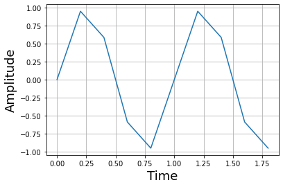

```python
#librerias
import numpy as np
import matplotlib.pyplot as plt
# para que la grafica se incruste en el notebook
%matplotlib inline

f=1.0 # Frecuencia de la senal
fs=5.0 # Frecuencia de muestreo
t=np.arange(0, 2.0, 1.0/fs) # Vector de tiempo
x = np.sin(2*np.pi*f*t)
print(x)
plt.plot(t,x)
plt.grid()
plt.xlabel('Time',fontsize=18)
plt.ylabel('Amplitude',fontsize=18)
plt.show()
```

#### 5.3.2) cambiar la frecuencia de muestreo fs=20Hz

```
[ 0.00000000e+00  3.09016994e-01  5.87785252e-01  8.09016994e-01
  9.51056516e-01  1.00000000e+00  9.51056516e-01  8.09016994e-01
  5.87785252e-01  3.09016994e-01  1.22464680e-16 -3.09016994e-01
 -5.87785252e-01 -8.09016994e-01 -9.51056516e-01 -1.00000000e+00
 -9.51056516e-01 -8.09016994e-01 -5.87785252e-01 -3.09016994e-01
 -2.44929360e-16  3.09016994e-01  5.87785252e-01  8.09016994e-01
  9.51056516e-01  1.00000000e+00  9.51056516e-01  8.09016994e-01
  5.87785252e-01  3.09016994e-01  3.67394040e-16 -3.09016994e-01
 -5.87785252e-01 -8.09016994e-01 -9.51056516e-01 -1.00000000e+00
 -9.51056516e-01 -8.09016994e-01 -5.87785252e-01 -3.09016994e-01]
```

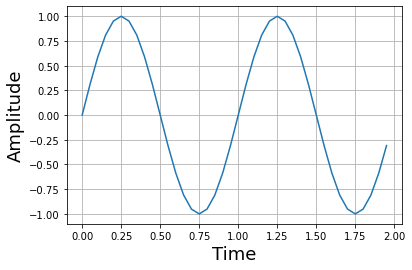

```python
import numpy as np
import matplotlib.pyplot as plt
%matplotlib inline
f=1.0 # Frecuencia de la senal
fs=20.0 # Frecuencia de muestreo
t=np.arange(0, 2.0, 1.0/fs) # Vector de tiempo
x = np.sin(2*np.pi*f*t)
print(x)
plt.plot(t,x)
plt.grid()
plt.xlabel('Time',fontsize=18)
plt.ylabel('Amplitude',fontsize=18)
plt.show()
```

#### se evidencia que al aumentar la frecuencia de muestreo se tiene mas puntos de muestra debidamente espaciados por lo que se puede contruir una señal senosoidal

#### 5.3.3) tasa de desempleo en colombia del periodo 2001-2017

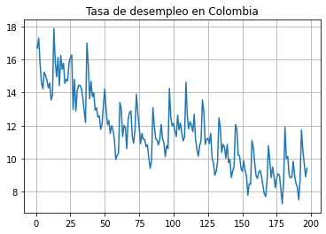

```python
import pandas as pd # libreria para el manejo de datos
# Leer datos
TD = pd.read_excel("TD.xlsx")
# Cambio de formato de los datos
TD = pd.DataFrame(TD)
# Extraigo una de las columnas del archivo de excel
TDC = TD["TD"]
index = TD["Index"]
#grafica de la tasa de desempleo
plt.plot(index, TDC)
plt.grid()
plt.title("Tasa de desempleo en Colombia")
```

#### #### la figura muestra que se tomaron alrrededor de 192 muestras, de las cuales cada una representa la tasa de desempleo en colombia de cada mes durante el periodo (2001-2017), donde se evidencia que los primeros tres años se tuvo una tasa de desempleo mayor al 14% y con el pasar de los años pudo bajar a una tasa menor al 12%

#### 5.3.4) señal de auido

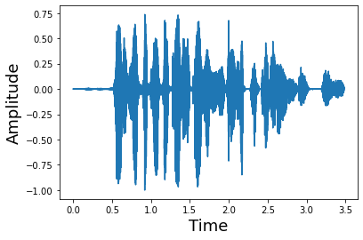

[interactive chart not shown]

```python
from scipy.io.wavfile import read # libreria para lectura de archivos de audio
from IPython.display import Audio # para escuchar la senal
audio=('senal.wav') # Ruta del archivo con la senal
fs,x=read(audio) # Cargar el archivo
x=x/float(max(abs(x))) # escala la amplitud de la senal
t=np.arange(0, float(len(x))/fs, 1.0/fs) # Vector de tiempo
plt.plot(t,x) # Dibujar la grafica
# Los siguientes dos comandos dibujan las etiquetas de los ejes
plt.xlabel('Time',fontsize=18) # Etiqueta eje X
plt.ylabel('Amplitude',fontsize=18) # Etiqueta eje Y
plt.show() # Mostrar la grafica
Audio(x, rate=fs) # para escuchar la senal, si se desea
```

#### 5.3.5) señal invertida

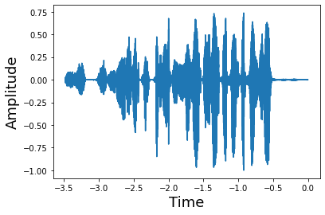

[interactive chart not shown]

```python
from scipy.io.wavfile import read # libreria para lectura de archivos de audio
from IPython.display import Audio # para escuchar la senal
audio=('senal.wav') # Ruta del archivo con la senal
fs,x=read(audio) # Cargar el archivo
x=x/float(max(abs(x))) # escala la amplitud de la senal
t=-np.arange(0, float(len(x))/fs, 1.0/fs) # Vector de tiempo
plt.plot(t,x) # Dibujar la grafica
# Los siguientes dos comandos dibujan las etiquetas de los ejes
plt.xlabel('Time',fontsize=18) # Etiqueta eje X
plt.ylabel('Amplitude',fontsize=18) # Etiqueta eje Y
plt.show() # Mostrar la grafica
Audio(x[::-1], rate=fs)
```

#### al invertir la señal no se puede escuchar de forma clara el mensaje

#### 5.3.6) Valor DC y energia de la señal

```python
def logEnergy(sig): # Definir la funcion
    sig2=np.square(sig) # Elevar al cuadrado las muestras de la senal
    sumsig2=np.sum(sig2) # Sumatoria
    logE=10*np.log10(sumsig2) # Convertir a dB
    dc=np.mean(sig) # Promedio
    return logE, dc
# Ahora se usa la funcion anterior para calcular las medidas de la senal
Energy, DCvalue = logEnergy(x)
print('Energia='+str(Energy))
print('Valor DC='+str(DCvalue))
```

```
Energia=32.83469047883786
Valor DC=3.1824252855484474e-05
```

# Laboratorio 1.2

#### 2) numero de euler

```python
def mifactorial(z):
    if z==0 or z==1:  #funcion que determina el factorial de 0 y/o 1
        solucion=1
        return solucion
    else:
        solucion=z*mifactorial(z-1)  #calcula factorial diferente a c0 y/o 1
        return solucion
def mieuler(x):
    i=0
    suma=0
    while i<=numero:
        suma=suma+(1/mifactorial(numero-i)) #utilizando el factorial, genera una suma progresiva para la aproximacion del euler
        i+=1
    return suma

#ingreso de dato por parte del usuario
numero=int(input("ingrese el numero de elementos a utilizar: "))
sol=mieuler(numero)
#impresion de dato
print("e es aproximadamente: {}".format(sol))
```

```
ingrese el numero de elementos a utilizar: 5
e es aproximadamente: 2.716666666666667
```

#### 2.2) nombre y edad

```python
lista=[]
nombre=0
edad=0
while nombre!="no mas":
    nombre=str(input("digite su nombre:"))
    if nombre != "no mas":
        edad=int(input("digite su edad:"))
        lista.append([edad,nombre])
for x1,x2 in lista:
    print(f"Hola {x1}, su edad es: {x2}")
    if x1>17:
        print("Usted es mayor de edad")
    else:
        print("usted es menor de edad")
```

```
digite su nombre:camilo
digite su edad:28
digite su nombre:luisa
digite su edad:32
digite su nombre:luciana
digite su edad:13
digite su nombre:liliana
digite su edad:60
digite su nombre:no mas
Hola 28, su edad es: camilo
Usted es mayor de edad
Hola 32, su edad es: luisa
Usted es mayor de edad
Hola 13, su edad es: luciana
usted es menor de edad
Hola 60, su edad es: liliana
Usted es mayor de edad
```

#### 3) una metrica

```python
import random #se importa la funcion random, genera numero aleatorio
dimension=int(input("ingrese las dimensiones de la matriz: ")) #dimension de la matriz
matriz=[]
suma=0
traza=0
for i in range(dimension):
    matriz.append([])
    for j in range(dimension):
        matriz[i].append(random.randrange(100))
        suma=suma+matriz[i][j]
        if i==j:
            traza=traza+matriz[i][j]
print("la metrica de la matriz es:",traza/suma)
print("matriz generada de forma aleatoria: {}".format(matriz))
```

```
ingrese las dimensiones de la matriz: 5
la metrica de la matriz es: 0.2359855334538879
matriz generada de forma aleatoria: [[51, 72, 53, 23, 19], [20, 33, 40, 90, 1], [46, 41, 92, 36, 43], [24, 59, 12, 48, 74], [66, 67, 9, 50, 37]]
```

#### 4) señal de longitud variable

```
Señor usuario ingrese su edad: 28
```

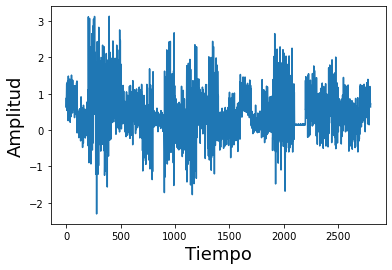

```
la matriz
 [0.86864383 0.62170241 0.81588634 0.89906791 1.23135373 1.27123048
 0.54090894 0.83992609 1.12159263 0.54563741 1.30656824 0.69353659
 1.07360108 0.81036325 1.35029847 1.16643718 0.87368674 0.75586294
 0.26023561 0.69813225 1.4853674  0.87439432 1.27274645 1.03577709
 1.14818714 1.08707798 0.92635623 0.73047755 0.67259419 0.90476252
 0.84877802 0.75087896 0.93497535 1.40410125 0.76450689 1.20788504
 0.9197665  0.21475765 0.87374732 1.09754313 1.14829655 0.85512297
 1.24888552 1.2835868  0.99036507 1.08577181 0.37189961 0.93878914
 0.78097737 1.51187498 1.11429331 0.97358014 0.71209483 1.1018474
 0.89213143 0.82790685 1.15315827 0.94508406 0.47081691 0.98003817
 1.37264002 0.96903983 0.56356432 0.60327358 0.63115624 0.75067239
 1.12510073 1.20914943 1.10654449 0.87747086 0.65290608 0.77726306
 1.21341526 0.86831529 0.65928495 0.82160388 0.65390768 0.34266439
 0.93513728 1.03641928 0.71422772 0.50051184 1.21926376 0.89833923
 0.85200362 1.20632167 1.05212888 0.56228239 0.64090446 1.02146536
 1.13349747 0.95309251 1.0716031  0.42384329 0.84592293 1.11868908
 1.30237138 0.40264704 0.75777114 1.34968419]

 media: 0.9148197438296496
desviacion estandar: 0.2752420182064761

la matriz
 [ 0.33980722 -0.07846914  0.79856294 -0.03079662  0.19928353  0.56517081
  0.30150978  0.32414038  0.42296407  0.46210907  0.23182225  0.25094399
  0.17092334  0.42497539 -0.01323579  0.4020876  -0.20855468  0.1843916
 -0.12422749  0.11994982  0.28399256  0.51448369  0.07627785  0.13516933
 -0.11968835  0.14642815  0.58732058  0.08191024  0.43065873  0.06890076
 -0.05560867  0.22159073 -0.16127165 -0.29811516  0.40311796  0.37817189
  0.64593642  0.91429735  0.07457327 -0.02225371  0.02898993  0.22662826
  0.08593968  0.30678039  0.16674355  0.42215952  0.05803884  0.6158003
  0.29058963  0.10662048  0.02670885 -0.47807192 -0.11200375  0.21196476
  0.02558393  0.08404582  0.16585259  0.0573213  -0.35770257  0.68342618
  0.65824482  0.08204939  0.24720053 -0.03604051  0.35026359 -0.05332879
  0.46693683  0.28035425  0.05949223  0.30510621  0.36389337  0.57292344
  0.41203229  0.21320468 -0.10152775  0.11739603 -0.2183635   0.24089949
  0.02954393  0.06811091 -0.15862447  0.31895559 -0.14991785  0.49298265
 -0.00721558  0.13434713  0.20372106  0.5546735   0.58885213  0.12894164
  0.17509342  0.77035594  0.171869    0.10065526  0.41071166 -0.14041714
  0.06308769  0.37155667 -0.04383778  0.29419706]
```

[output cut: 600 more lines]

```
  0.5177952   0.59848903  1.1254606   0.61142671  0.56104893  0.54626518
  0.27674145  0.79172991  0.615967    0.83897957  1.26055385  0.43584473
  0.73680758  0.29351107  0.82416124  0.8918089   0.61211157  0.68479565
  0.96930231  0.57620115 -0.04513933  0.58486197  1.01588911  1.17878035
  0.96458029  0.65991347  1.14345072  0.80851935  0.6027052   0.7932025
  0.68705837  1.05803289  0.50403307  0.34380547  0.61100072  1.30392305
  0.82470154  0.50396706  0.70786364  0.60232686  0.85877778  0.41457347
  0.58495448  0.16748204  0.40279283  1.39545261  0.49162912  1.31324173
  1.15800358  0.93855045  0.79296888  0.80539457  0.25548022  0.86985738
  0.79391104  0.52195586  0.14545108  0.7843205   0.72643615  0.74034282
  1.06173626  1.08145787  0.9886137   1.19915498  1.18212756  0.74522535
  0.99346329  0.6866981   0.74217709  0.63681014]

 media: 0.7517886794922441
desviacion estandar: 0.30099987941371936
```

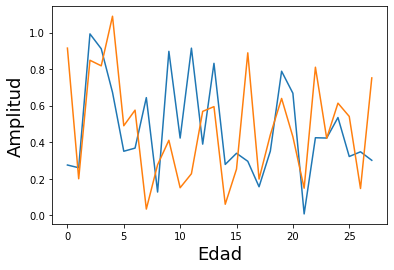

```python
import numpy as np
import matplotlib.pyplot as plt
%matplotlib inline

#ingreso de edad
edad= int(input("Señor usuario ingrese su edad: "))
senal=np.empty((0,))
matriz=np.empty((0,100))
mmedi=[]
mdesvi=[]
for i in range(edad):
    ventana=np.random.rand()*np.random.randn(100)+np.random.rand()
    senal=np.hstack((senal,ventana))
    matriz=np.vstack((matriz,ventana))

#imprimir señal
plt.plot(senal)
plt.xlabel('Tiempo',fontsize=18)
plt.ylabel('Amplitud',fontsize=18)
plt.show()
for i in matriz:
    media=np.mean(i)  #media o promedio de una lista
    desvi=np.std(i)   #desviacion estandar
    mmedi.append(media)
    mdesvi.append(desvi)
    print('la matriz \n',i)
    print("\n media: {}".format(media))
    print("desviacion estandar: {} \n".format(desvi))
plt.plot(mdesvi)
plt.plot(mmedi)
plt.xlabel('Edad',fontsize=18)
plt.ylabel('Amplitud',fontsize=18)
plt.show()
```